# Data Wrangling with R

[figure not shown]

# Lab | Data Wrangling with R

## Objective

Practice data wrangling, cleaning, and manipulation techniques in R using the **Sample Super Store** dataset. By the end of this activity, you should be able to:

- Load and explore the dataset.
- Perform basic and advanced data manipulations.
- Handle missing data and duplicates.
- Aggregate and summarize data.
- Dataset Overview.

The Sample Super Store dataset contains sales, profit, and customer information for a retail store. It includes columns such as:

- Order ID, Order Date, Ship Date
- Customer ID, Customer Name, Segment
- City, State, Region, Category, Sub-Category
- Sales, Quantity, Discount, Profit

## Instructions

### Step 1: Load and Explore the Dataset

1. Load the dataset into R.

```r
library(readr)

# Loading the Dataset
df <- read.csv("/Users/guillermo/Documents/Ironhack/Datasets/Sample - Superstore/Sample - Superstore.csv")
```

```r
library(dplyr)
```

1. Explore the dataset using str(), head(), and summary().

```r
str(df)
```

```
'data.frame':   9994 obs. of  21 variables:
 $ Row.ID       : int  1 2 3 4 5 6 7 8 9 10 ...
 $ Order.ID     : chr  "CA-2016-152156" "CA-2016-152156" "CA-2016-138688" "US-2015-108966" ...
 $ Order.Date   : chr  "11/8/2016" "11/8/2016" "6/12/2016" "10/11/2015" ...
 $ Ship.Date    : chr  "11/11/2016" "11/11/2016" "6/16/2016" "10/18/2015" ...
 $ Ship.Mode    : chr  "Second Class" "Second Class" "Second Class" "Standard Class" ...
 $ Customer.ID  : chr  "CG-12520" "CG-12520" "DV-13045" "SO-20335" ...
 $ Customer.Name: chr  "Claire Gute" "Claire Gute" "Darrin Van Huff" "Sean O'Donnell" ...
 $ Segment      : chr  "Consumer" "Consumer" "Corporate" "Consumer" ...
 $ Country      : chr  "United States" "United States" "United States" "United States" ...
 $ City         : chr  "Henderson" "Henderson" "Los Angeles" "Fort Lauderdale" ...
 $ State        : chr  "Kentucky" "Kentucky" "California" "Florida" ...
 $ Postal.Code  : int  42420 42420 90036 33311 33311 90032 90032 90032 90032 90032 ...
 $ Region       : chr  "South" "South" "West" "South" ...
 $ Product.ID   : chr  "FUR-BO-10001798" "FUR-CH-10000454" "OFF-LA-10000240" "FUR-TA-10000577" ...
 $ Category     : chr  "Furniture" "Furniture" "Office Supplies" "Furniture" ...
 $ Sub.Category : chr  "Bookcases" "Chairs" "Labels" "Tables" ...
 $ Product.Name : chr  "Bush Somerset Collection Bookcase" "Hon Deluxe Fabric Upholstered Stacking Chairs, Rounded Back" "Self-Adhesive Address Labels for Typewriters by Universal" "Bretford CR4500 Series Slim Rectangular Table" ...
 $ Sales        : num  262 731.9 14.6 957.6 22.4 ...
 $ Quantity     : int  2 3 2 5 2 7 4 6 3 5 ...
 $ Discount     : num  0 0 0 0.45 0.2 0 0 0.2 0.2 0 ...
 $ Profit       : num  41.91 219.58 6.87 -383.03 2.52 ...
```

```r
head(df)
```

|  | Row.ID | Order.ID | Order.Date | Ship.Date | Ship.Mode | Customer.ID | Customer.Name | Segment | Country | City | State | Postal.Code | Region | Product.ID | Category | Sub.Category | Product.Name | Sales | Quantity | Discount | Profit |
| --- | --- | --- | --- | --- | --- | --- | --- | --- | --- | --- | --- | --- | --- | --- | --- | --- | --- | --- | --- | --- | --- |
| 1 | 1 | CA-2016-152156 | 11/8/2016 | 11/11/2016 | Second Class | CG-12520 | Claire Gute | Consumer | United States | Henderson | Kentucky | 42420 | South | FUR-BO-10001798 | Furniture | Bookcases | Bush Somerset Collection Bookcase | 261.9600 | 2 | 0.00 | 41.9136 |
| 2 | 2 | CA-2016-152156 | 11/8/2016 | 11/11/2016 | Second Class | CG-12520 | Claire Gute | Consumer | United States | Henderson | Kentucky | 42420 | South | FUR-CH-10000454 | Furniture | Chairs | Hon Deluxe Fabric Upholstered Stacking Chairs, Rounded Back | 731.9400 | 3 | 0.00 | 219.5820 |
| 3 | 3 | CA-2016-138688 | 6/12/2016 | 6/16/2016 | Second Class | DV-13045 | Darrin Van Huff | Corporate | United States | Los Angeles | California | 90036 | West | OFF-LA-10000240 | Office Supplies | Labels | Self-Adhesive Address Labels for Typewriters by Universal | 14.6200 | 2 | 0.00 | 6.8714 |
| 4 | 4 | US-2015-108966 | 10/11/2015 | 10/18/2015 | Standard Class | SO-20335 | Sean O'Donnell | Consumer | United States | Fort Lauderdale | Florida | 33311 | South | FUR-TA-10000577 | Furniture | Tables | Bretford CR4500 Series Slim Rectangular Table | 957.5775 | 5 | 0.45 | -383.0310 |
| 5 | 5 | US-2015-108966 | 10/11/2015 | 10/18/2015 | Standard Class | SO-20335 | Sean O'Donnell | Consumer | United States | Fort Lauderdale | Florida | 33311 | South | OFF-ST-10000760 | Office Supplies | Storage | Eldon Fold 'N Roll Cart System | 22.3680 | 2 | 0.20 | 2.5164 |
| 6 | 6 | CA-2014-115812 | 6/9/2014 | 6/14/2014 | Standard Class | BH-11710 | Brosina Hoffman | Consumer | United States | Los Angeles | California | 90032 | West | FUR-FU-10001487 | Furniture | Furnishings | Eldon Expressions Wood and Plastic Desk Accessories, Cherry Wood | 48.8600 | 7 | 0.00 | 14.1694 |

```r
summary(df)
```

```
     Row.ID       Order.ID          Order.Date         Ship.Date
 Min.   :   1   Length:9994        Length:9994        Length:9994
 1st Qu.:2499   Class :character   Class :character   Class :character
 Median :4998   Mode  :character   Mode  :character   Mode  :character
 Mean   :4998
 3rd Qu.:7496
 Max.   :9994
  Ship.Mode         Customer.ID        Customer.Name        Segment
 Length:9994        Length:9994        Length:9994        Length:9994
 Class :character   Class :character   Class :character   Class :character
 Mode  :character   Mode  :character   Mode  :character   Mode  :character



   Country              City              State            Postal.Code
 Length:9994        Length:9994        Length:9994        Min.   : 1040
 Class :character   Class :character   Class :character   1st Qu.:23223
 Mode  :character   Mode  :character   Mode  :character   Median :56430
                                                          Mean   :55190
                                                          3rd Qu.:90008
                                                          Max.   :99301
    Region           Product.ID          Category         Sub.Category
 Length:9994        Length:9994        Length:9994        Length:9994
 Class :character   Class :character   Class :character   Class :character
 Mode  :character   Mode  :character   Mode  :character   Mode  :character



 Product.Name           Sales              Quantity        Discount
 Length:9994        Min.   :    0.444   Min.   : 1.00   Min.   :0.0000
 Class :character   1st Qu.:   17.280   1st Qu.: 2.00   1st Qu.:0.0000
 Mode  :character   Median :   54.490   Median : 3.00   Median :0.2000
                    Mean   :  229.858   Mean   : 3.79   Mean   :0.1562
                    3rd Qu.:  209.940   3rd Qu.: 5.00   3rd Qu.:0.2000
                    Max.   :22638.480   Max.   :14.00   Max.   :0.8000
     Profit
 Min.   :-6599.978
 1st Qu.:    1.729
 Median :    8.666
 Mean   :   28.657
 3rd Qu.:   29.364
 Max.   : 8399.976
```

1. Identify the number of rows and columns.

```r
nrow(df)
```

```
[1] 9994
```

```r
ncol(df)
```

```
[1] 21
```

```r
dim(df)
```

```
[1] 9994   21
```

```r
number_of_rows <- nrow(df)
number_of_columns <- ncol(df)

# Print the number of rows and columns
print(paste("Number of rows:", number_of_rows))
```

```
[1] "Number of rows: 9994"
```

```r
print(paste("Number of columns:", number_of_columns))
```

```
[1] "Number of columns: 21"
```

```r
names(df)
```

```
 [1] "Row.ID"        "Order.ID"      "Order.Date"    "Ship.Date"     "Ship.Mode"
 [6] "Customer.ID"   "Customer.Name" "Segment"       "Country"       "City"
[11] "State"         "Postal.Code"   "Region"        "Product.ID"    "Category"
[16] "Sub.Category"  "Product.Name"  "Sales"         "Quantity"      "Discount"
[21] "Profit"
```

```r
# Assuming your data frame is named 'df'
column_names <- names(df)

# Print the column names
print(column_names)
```

```
 [1] "Row.ID"        "Order.ID"      "Order.Date"    "Ship.Date"     "Ship.Mode"
 [6] "Customer.ID"   "Customer.Name" "Segment"       "Country"       "City"
[11] "State"         "Postal.Code"   "Region"        "Product.ID"    "Category"
[16] "Sub.Category"  "Product.Name"  "Sales"         "Quantity"      "Discount"
[21] "Profit"
```

### Step 2: Basic Data Manipulation

1. Select the following columns: Order ID, Order Date, Customer Name, Sales, Profit.

```r
store_subset_sales <- select(df, Order.ID, Order.Date, Customer.Name, Sales, Profit)
```

1. Filter the dataset to show only orders with a profit greater than $100.

```r
profit_from_100 <- filter(df, Profit > 100)
```

1. Sort the dataset by Sales in descending order.

```r
df_sorted <- arrange(df, desc(Sales))
```

### Step 3: Handle Missing Data

1. Check for missing values in the dataset.

```r
# Set the first row of the 'Postal.Code' column to NA
df$Postal.Code[1] <- NA
df$Customer.Name[1] <- NA
```

```r
missing_values_per_column <- colSums(is.na(df))
any(is.na(df)) # Use this if you only need to know if there are any missing values in the entire dataset.
```

```
[1] TRUE
```

```r
print(missing_values_per_column)
```

```
       Row.ID      Order.ID    Order.Date     Ship.Date     Ship.Mode   Customer.ID
            0             0             0             0             0             0
Customer.Name       Segment       Country          City         State   Postal.Code
            1             0             0             0             0             1
       Region    Product.ID      Category  Sub.Category  Product.Name         Sales
            0             0             0             0             0             0
     Quantity      Discount        Profit
            0             0             0
```

1. Replace missing values in the Postal Code column with the mode (most frequent value).

```r
calculate_mode <- function(x) {
  unique_x <- unique(x)
  unique_x[which.max(tabulate(match(x, unique_x)))]
}

#df <- df %>% mutate(Postal.Code = ifelse(is.na(Postal.Code), mode(Postal.Code), Postal.Code))
df <- df %>%
  mutate(Postal.Code = ifelse(is.na(Postal.Code), calculate_mode(na.omit(Postal.Code)), Postal.Code))
```

1. Remove rows with missing values in the Customer Name column.

```r
clean_df <- df %>%
  filter(!is.na(Customer.Name))
```

### Step 4: Create and Modify Columns

1. Create a new column Profit_Margin as the ratio of Profit to Sales.

```r
df$Profit_Margin <- df$Profit / df$Sales
```

1. Create a new column Order_Year by extracting the year from Order Date.

```r
# Load stringr and forcats
library(stringr)
library(forcats)
# Extract the year from Order Date.
df <- df %>%
  mutate(Order_Year = str_extract(Order.Date, "\\d{4}$"))
```

1. Convert the Order.Date column to a Date data type.

```r
df$Order.Date <- as.Date(df$Order.Date, format = "%m/%d/%Y")
```

### Step 5: Aggregating and Summarizing Data

1. Calculate the total sales and profit by Category.

```r
category_summary <- df %>% group_by(Category) %>%
              summarize(
                Total_Sales = sum(Sales, na.rm = TRUE),
                Total_Profit = sum(Profit, na.rm = TRUE)
              )
```

1. Find the average profit margin by Region.

```r
profit_margen_region <- df %>% group_by(Region) %>%
              summarize(
                Total_Sales = mean(Profit_Margin, na.rm = TRUE)
              )
```

1. Count the number of orders by Customer Segment.

```r
orders_by_segment <- df %>%
  group_by(Segment) %>%
  summarize(Order_Count = n())
```

## Optional

### Extra 1: Advanced Challenges

1. Identify and remove duplicate rows based on Order ID.
2. Create a new column Discount_Level that categorizes discounts as “Low” (<10%), “Medium” (10-20%), and “High” (>20%).

```r
# Remove duplicate rows based on Order ID
orders_df_no_duplicates <- df %>%
  distinct(Order.ID, .keep_all = TRUE)



df2 <- df %>%
  mutate(Discount_Level = case_when(
    Discount < 0.1 ~ "Low",
    Discount >= 0.1 & Discount < 0.2 ~ "Medium",
    Discount >= 0.2 ~ "High",
  ))
```

1. Merge the dataset with a new dataset containing regional population data (create a dummy dataset for this purpose).

```r
# Create a dummy population dataset
population_data <- data.frame(
  Region = c("East", "West","Central", "South", "North"),
  Population = c(1500000, 2000000, 500000, 1200000, 1800000)  # Example population values
)
```

```r
unique(df$Region)
```

```
[1] "South"   "West"    "Central" "East"
```

```r
# Merge the datasets based on the Region column
merged_data <- merge(df, population_data, by = "Region")
```

### Extra 2: Data Visualization

Next class we will talk about data visualization, but let’s see if you can pull it off on your own.

1. Create a bar plot of total sales by Category.

```r
category_total_sales <- df %>%
  group_by(Category) %>%
    summarise(Total_Sales = sum(Sales))

ggplot(category_total_sales, aes(x = Category, y = Total_Sales)) +
  geom_bar(stat = "identity", fill = "skyblue") +  # Use "identity" to plot actual values
  labs(title = "Total Sales by Category",
       x = "Category",
       y = "Total Sales") +
      theme(axis.text.x = element_text(angle = 45, hjust = 1))  # Rotate x-axis labels for readability
```

[output not shown]

```
Error in ggplot(category_total_sales, aes(x = Category, y = Total_Sales)) :
  could not find function "ggplot"
```

2. Create a scatter plot of Sales vs. Profit with a trend line.
3. Create a histogram of Profit_Margin.

```r
# Check the range of the Profit_Margin column
range(df$Profit_Margin, na.rm = TRUE)
```

```
[1] -2.75  0.50
```

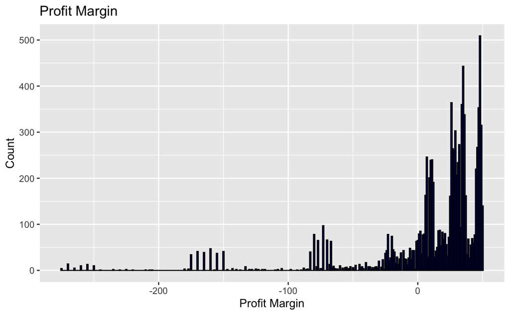

```r
library(ggplot2)

ggplot(df, aes(x = Profit_Margin*100)) +
  geom_histogram(binwidth = 1, fill = "blue", color = "black") +
  labs(title = "Profit Margin", x = "Profit Margin", y = "Count")
```